# Homework 2

Akeem Ajede

10/4/2019

# Q. 1b(i)

Sketch the pdf of U(0,10).

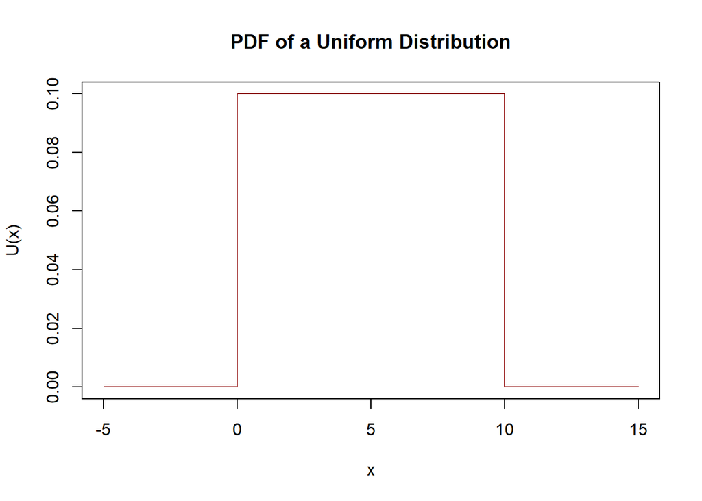

# Q.1b(ii)

Sketch the cdf of U(0,10).

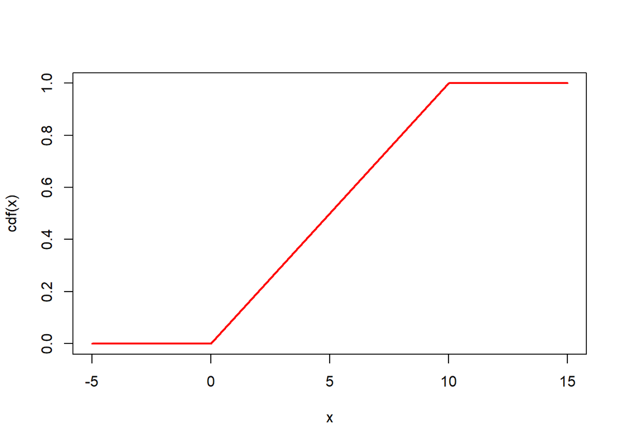

# Q. 1c(i)

Use R to generate a random sample of size 50 from Uniform(0, 10) and plot the histogram (overlaid with the true pdf).

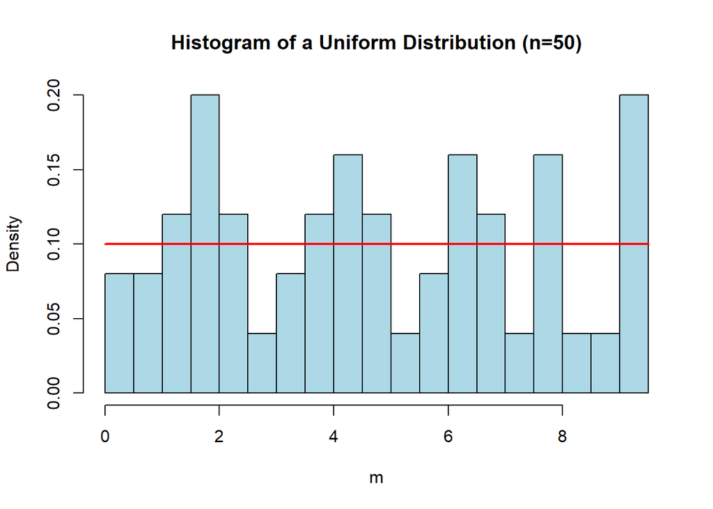

# Q. 1c(ii)

plot the emperical cdf overlaid with the theoretical cdf.

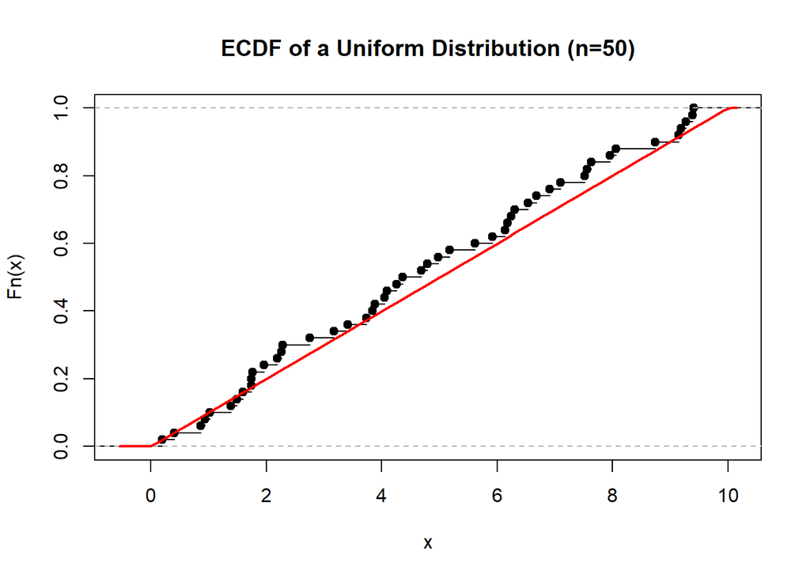

# Q. 1d(i)

Use R to generate a random sample of size 1000 from Uniform(0, 10) and plot the histogram (overlaid with the true pdf).

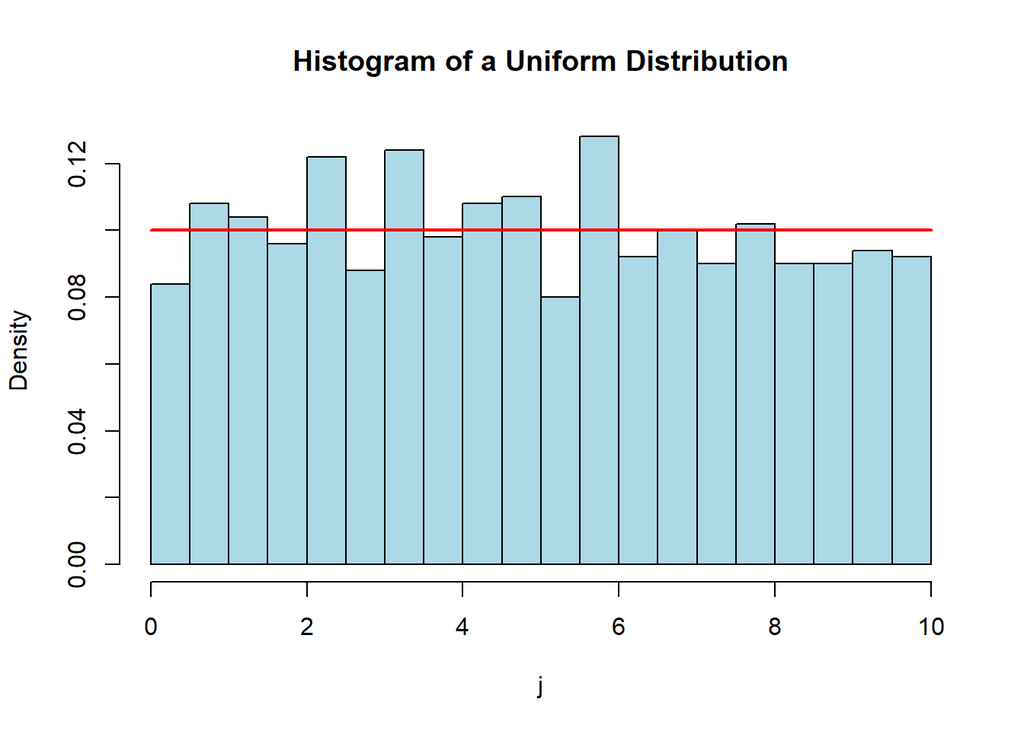

# Q. 1d(ii)

Plot the emperical cdf overlaid with the theoretical cdf.

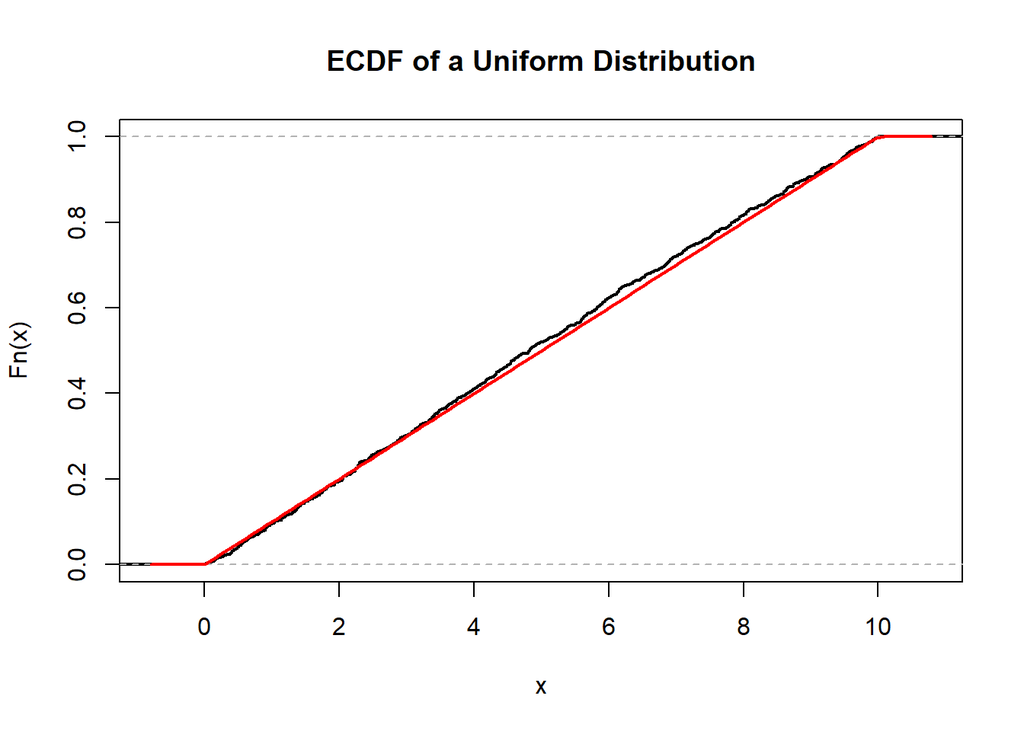

# Q. 2d

Use R to generate 1000 independent random samples of size 30 from Uniform(0, 10). Compute the corresponding 1000 values of $\bf\hat{\theta_1},\bf\hat{\theta_2},\bf\hat{\theta_3}.$

# Q. 2d(i)

For each estimator, draw the histograms based on their 1000 estimates. Include the theoretical pdf overlayed. For $\bf\hat{\theta_1},$ you can use the approximate distribution in part (c).

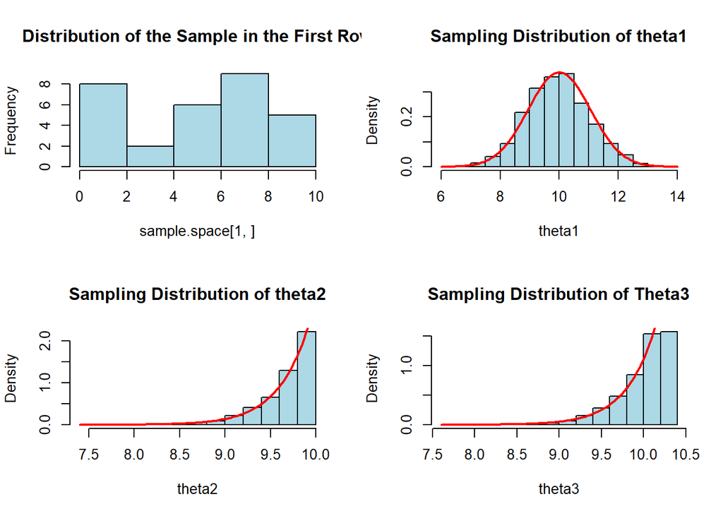

# Q. 2d(ii)

For each estimator, draw the ecdf based on their 1000 estimates. Include the theoretical cdf overlayed. For $\bf\hat{\theta_1},$ you can use the approximate distribution in part (c).

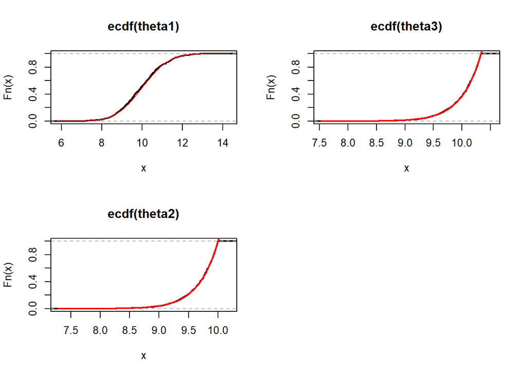

# Q. 2d(iii)

Compute the empirical bias, variance and MSE for each of the estimators. Compare and contrast. Note: $bias\bf\hat{(\theta_1})$ = $\bf\bar{\hat{(\theta_1})}$ − $\bf{\theta}$ and MSE can be computed as above or recall, $MSE = Var + bias^2.$

```
## [1] TRUE
```

```
## [1] TRUE
```

```
## [1] TRUE
```

Since $MSE_3$ is less than both $MSE_1$ and $MSE_2$, $MSE_3$ (i.e.,the mean square error of the modified MLE) has the least residual error for a 1000 uniform random samples of size 30.